# R Notebook

```r
library(curl)
library(Rmisc)
```

```r
library(ggplot2)
f <- curl("https://raw.githubusercontent.com/fuzzyatelin/fuzzyatelin.github.io/master/AN588_Fall21/zombies.csv")
d <- read.csv(f, header = TRUE, sep = ",", stringsAsFactors = FALSE)
head(d)
```

|  | id | first_name | last_name | gender | height | weight | zombies_killed | years_of_education | major | age |
| --- | --- | --- | --- | --- | --- | --- | --- | --- | --- | --- |
| 1 | 1 | Sarah | Little | Female | 62.88951 | 132.0872 | 2 | 1 | medicine/nursing | 17.64275 |
| 2 | 2 | Mark | Duncan | Male | 67.80277 | 146.3753 | 5 | 3 | criminal justice administration | 22.58951 |
| 3 | 3 | Brandon | Perez | Male | 72.12908 | 152.9370 | 1 | 1 | education | 21.91276 |
| 4 | 4 | Roger | Coleman | Male | 66.78484 | 129.7418 | 5 | 6 | energy studies | 18.19058 |
| 5 | 5 | Tammy | Powell | Female | 64.71832 | 132.4265 | 4 | 3 | logistics | 21.10399 |
| 6 | 6 | Anthony | Green | Male | 71.24326 | 152.5246 | 1 | 4 | energy studies | 21.48355 |

1. Calculate the population mean and standard deviation for each quantitative random variable (height, weight, age, number of zombies killed, and years of education). NOTE: You will not want to use the built in var() and sd() commands as these are for samples.

```r
# Wrong sd, smaple not population

# pop_v <- function(x) {
# sum((x - mean(x))^2)/(length(x))
# }
# pop_sd <- function(x) {
#    sqrt(pop_v(x))
# }
# pop_sd(d$height)

height_sum <- summarySE(data = d, measurevar = "height")
height_sum
```

| .id | N | height | sd | se | ci |
| --- | --- | --- | --- | --- | --- |
| NA | 1000 | 67.6301 | 4.310126 | 0.1362981 | 0.2674635 |

```r
weight_sum <- summarySE(data = d, measurevar = "weight")
weight_sum
```

| .id | N | weight | sd | se | ci |
| --- | --- | --- | --- | --- | --- |
| NA | 1000 | 143.9075 | 18.40106 | 0.5818926 | 1.141872 |

```r
kill_sum <- summarySE(data = d, measurevar = "zombies_killed")
kill_sum
```

| .id | N | zombies_killed | sd | se | ci |
| --- | --- | --- | --- | --- | --- |
| NA | 1000 | 2.992 | 1.748426 | 0.05529008 | 0.108498 |

```r
educate_sum <- summarySE(data = d, measurevar = "years_of_education")
educate_sum
```

| .id | N | years_of_education | sd | se | ci |
| --- | --- | --- | --- | --- | --- |
| NA | 1000 | 2.996 | 1.676543 | 0.05301693 | 0.1040373 |

```r
age_sum <- summarySE(data = d, measurevar = "age")
age_sum
```

| .id | N | age | sd | se | ci |
| --- | --- | --- | --- | --- | --- |
| NA | 1000 | 20.04696 | 2.965066 | 0.09376361 | 0.1839962 |

2. Use {ggplot} to make boxplots of each of these variables by gender.

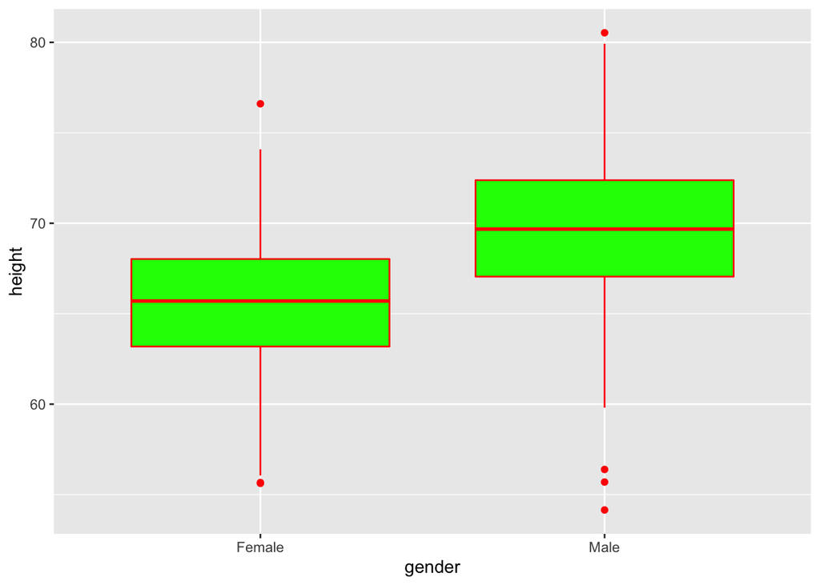

```r
ggplot(data = d, aes(x = gender, y = height)) +
  geom_boxplot(color="red", fill = "green")
```

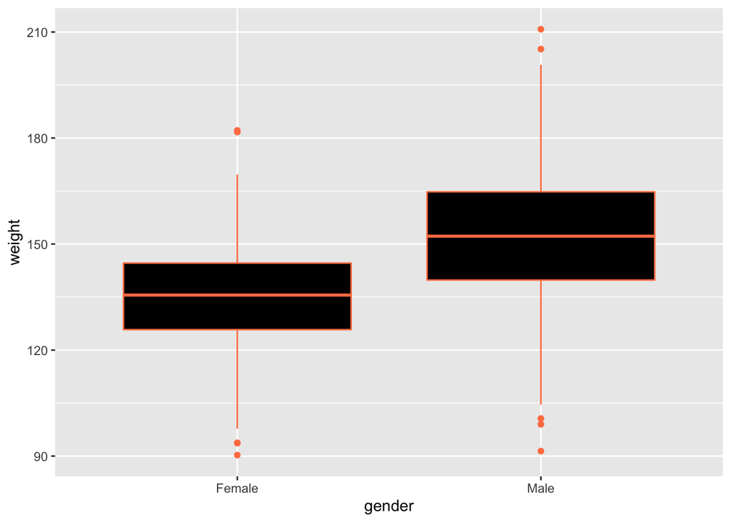

```r
ggplot(data = d, aes(x = gender, y = weight)) +
  geom_boxplot(color="coral", fill="black")
```

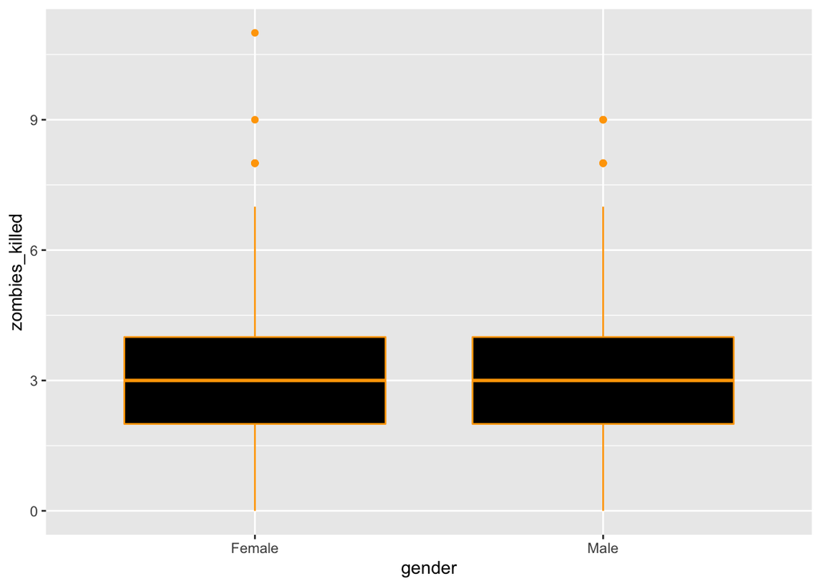

```r
ggplot(data = d, aes(x = gender, y = zombies_killed)) +
  geom_boxplot(color="orange", fill="black")
```

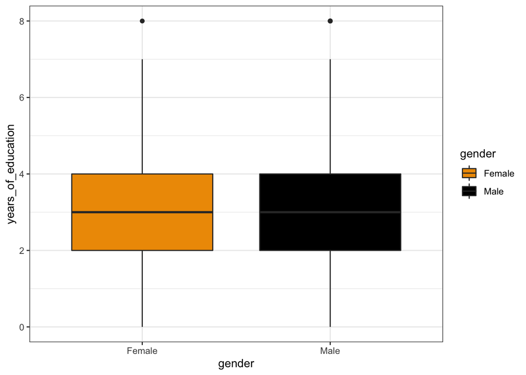

```r
ggplot(data = d, aes(x = gender, y = years_of_education, fill=gender)) +
  geom_boxplot() + scale_fill_manual(values=c("orange2", "black")) + theme_bw()
```

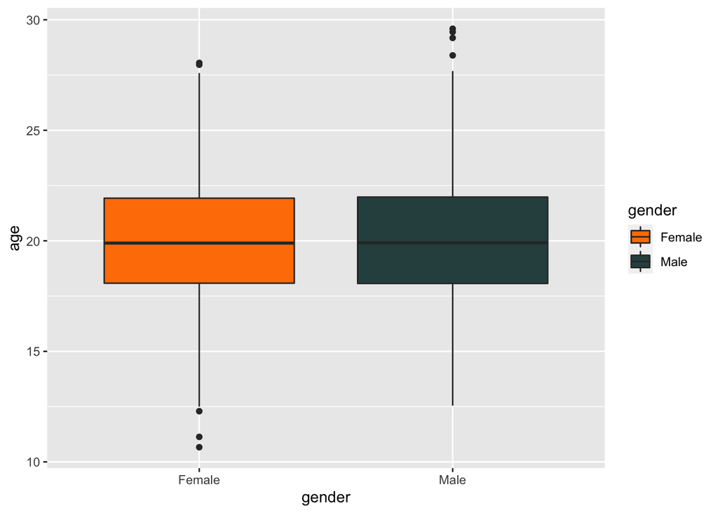

```r
ggplot(data = d, aes(x = gender, y = age, fill=gender)) +
  geom_boxplot() + scale_fill_manual(values=c("darkorange1", "darkslategray"))
```

3. Use {ggplot} to make scatterplots of height and weight in relation to age. Do these variables seem to be related? In what way?

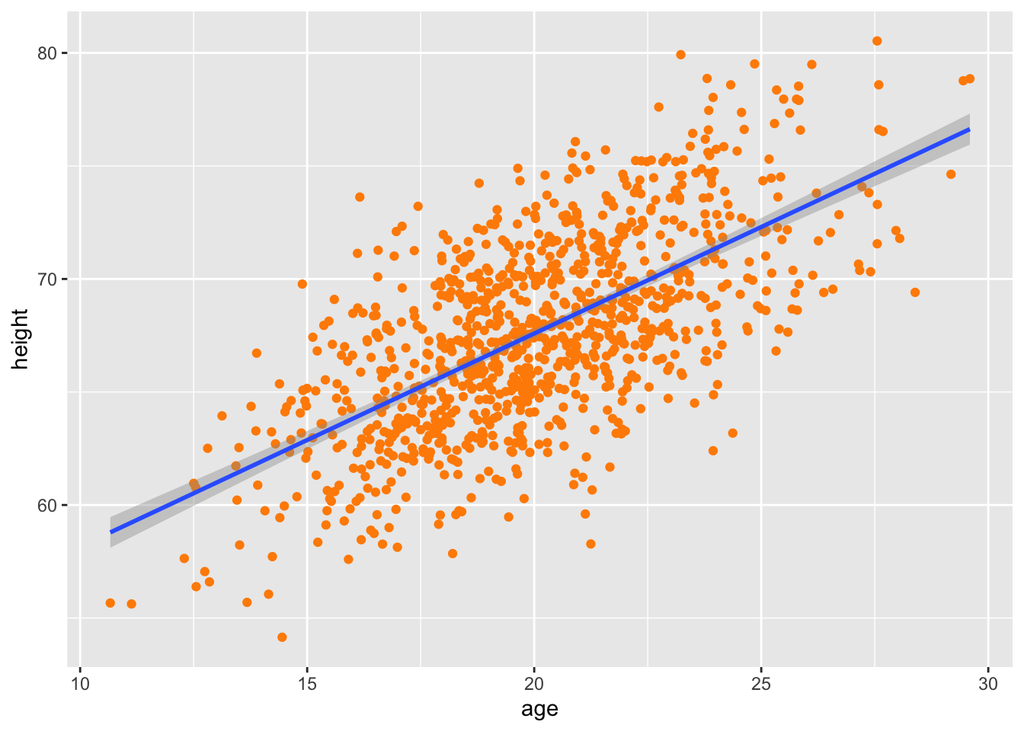

```r
ggplot(data = d, aes(x = age, y = height)) +
  geom_point(color="darkorange") + geom_smooth(method = lm)
```

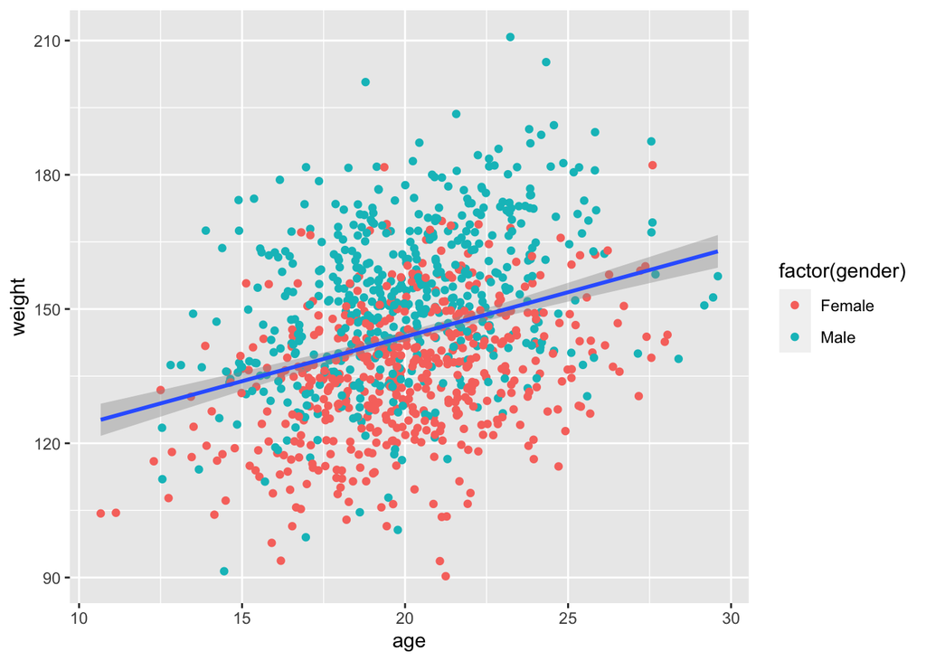

```r
ggplot(data = d, aes(x = age, y = weight)) +
  geom_point(aes(colour = factor(gender))) + geom_smooth(method = lm)
```

```r
# Yes both height and weight seem to be positivly coorelated with age
```

4. Using histograms and Q-Q plots, check whether the quantitative variables seem to be drawn from a normal distribution. Which seem to be and which do not (hint: not all are drawn from the normal distribution)? For those that are not normal, can you determine from which common distribution they are drawn?

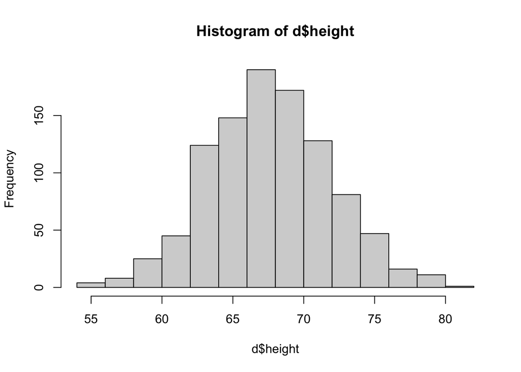

```r
hist(d$height)
```

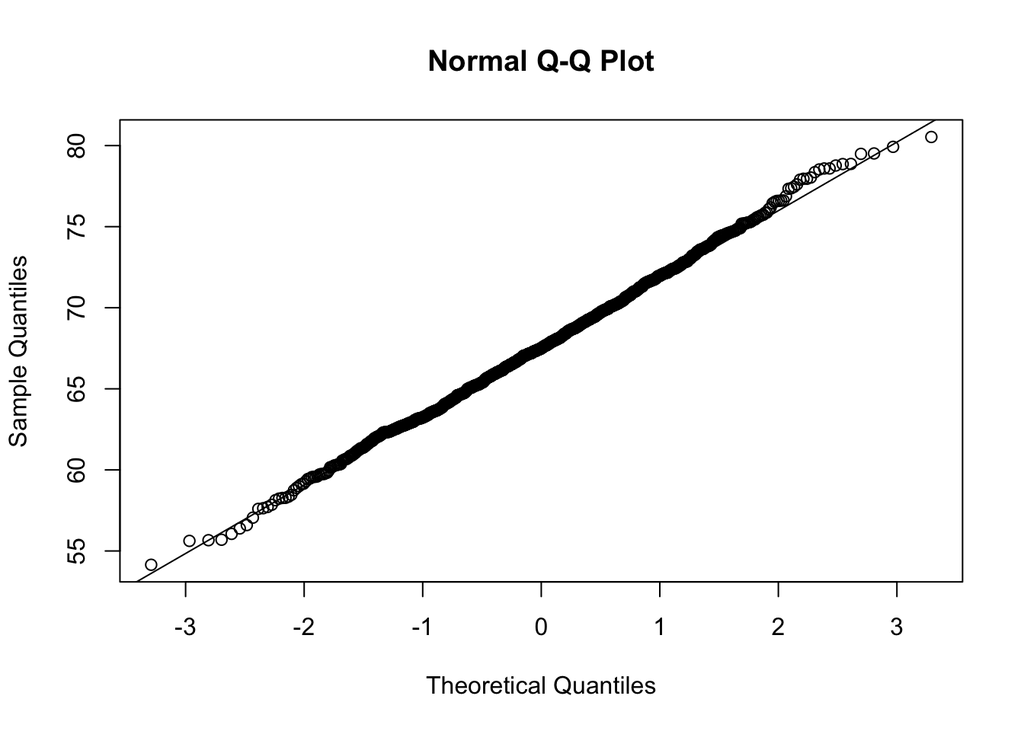

```r
qqnorm(d$height)
qqline(d$height)
```

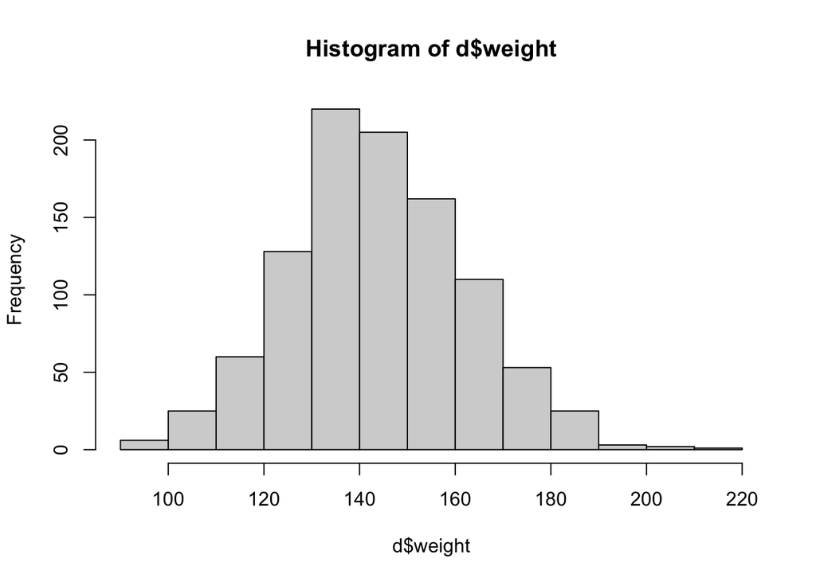

```r
# Height seems to follow a normal distribution

hist(d$weight)
```

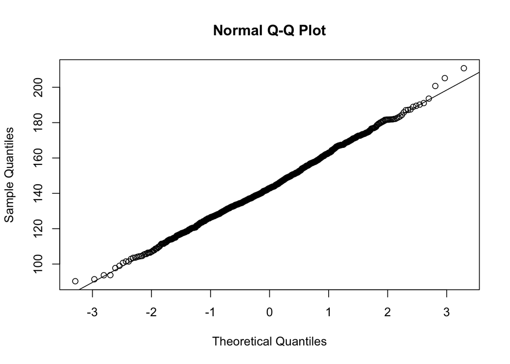

```r
qqnorm(d$weight)
qqline(d$weight)
```

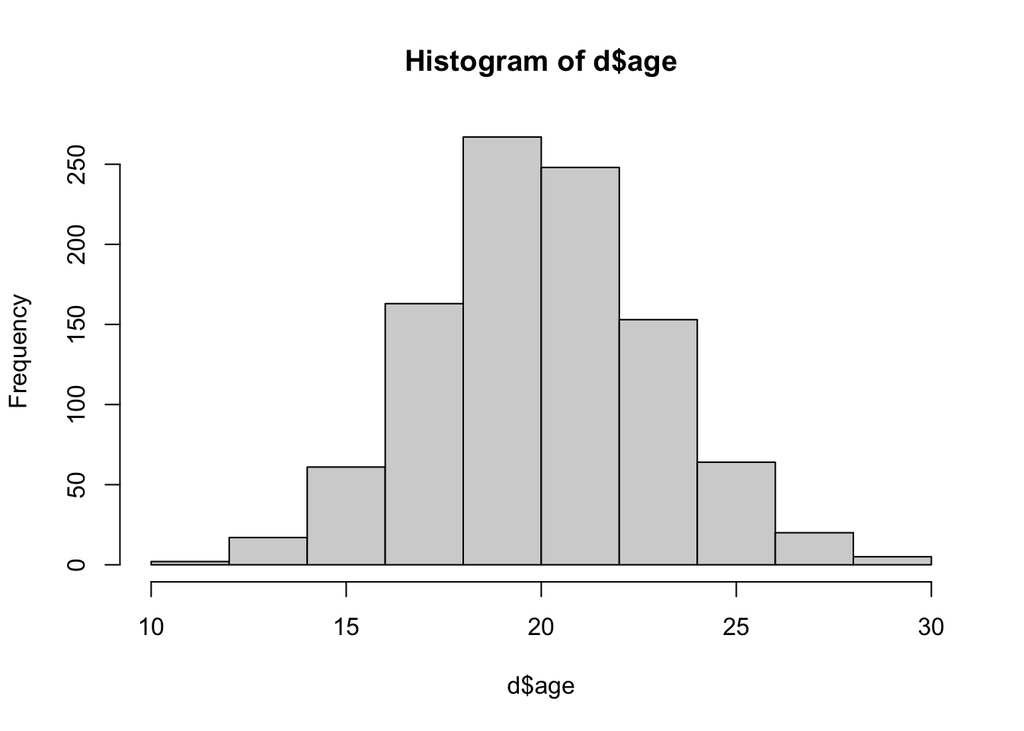

```r
# Weight seems to follow a normal distribution

hist(d$age)
```

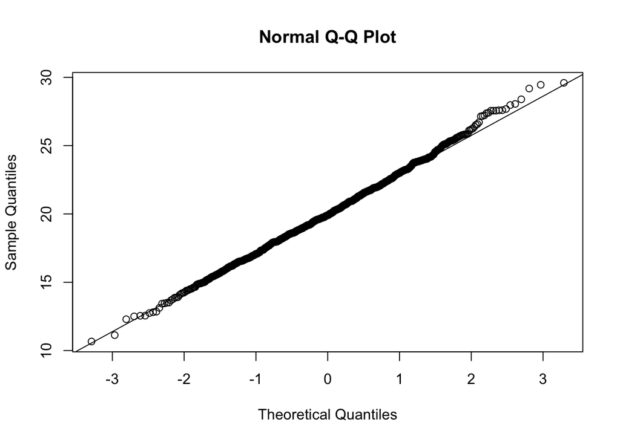

```r
qqnorm(d$age)
qqline(d$age)
```

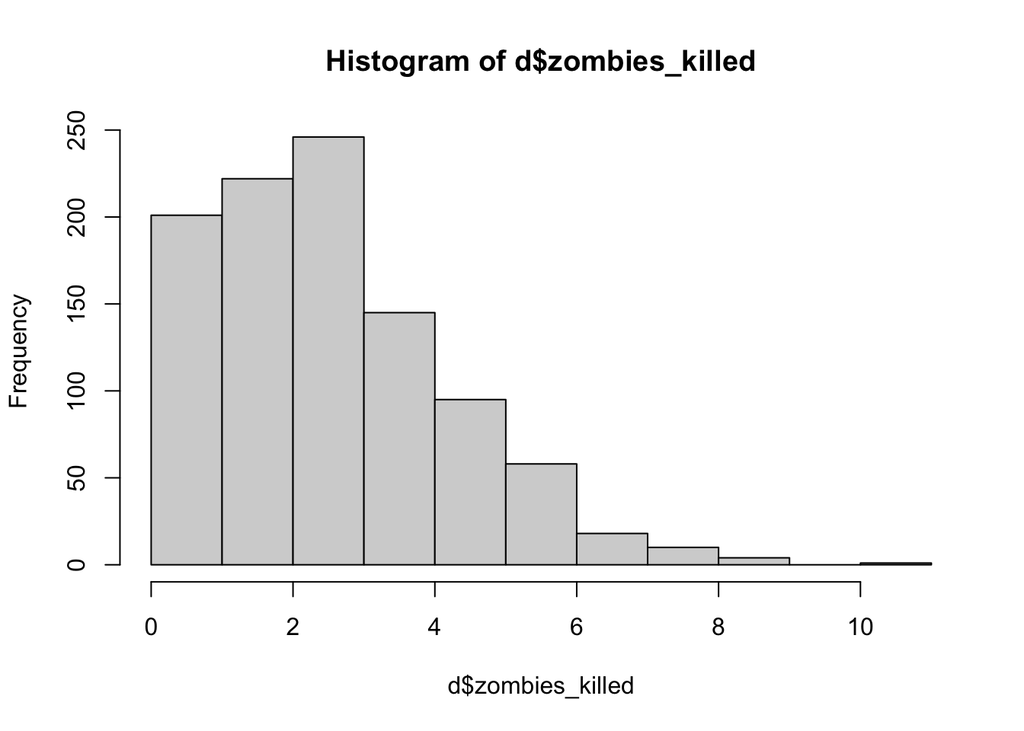

```r
# Age follows a normal distribution

hist(d$zombies_killed)
```

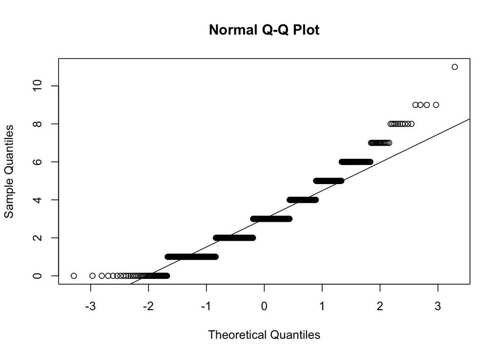

```r
qqnorm(d$zombies_killed)
qqline(d$zombies_killed)
```

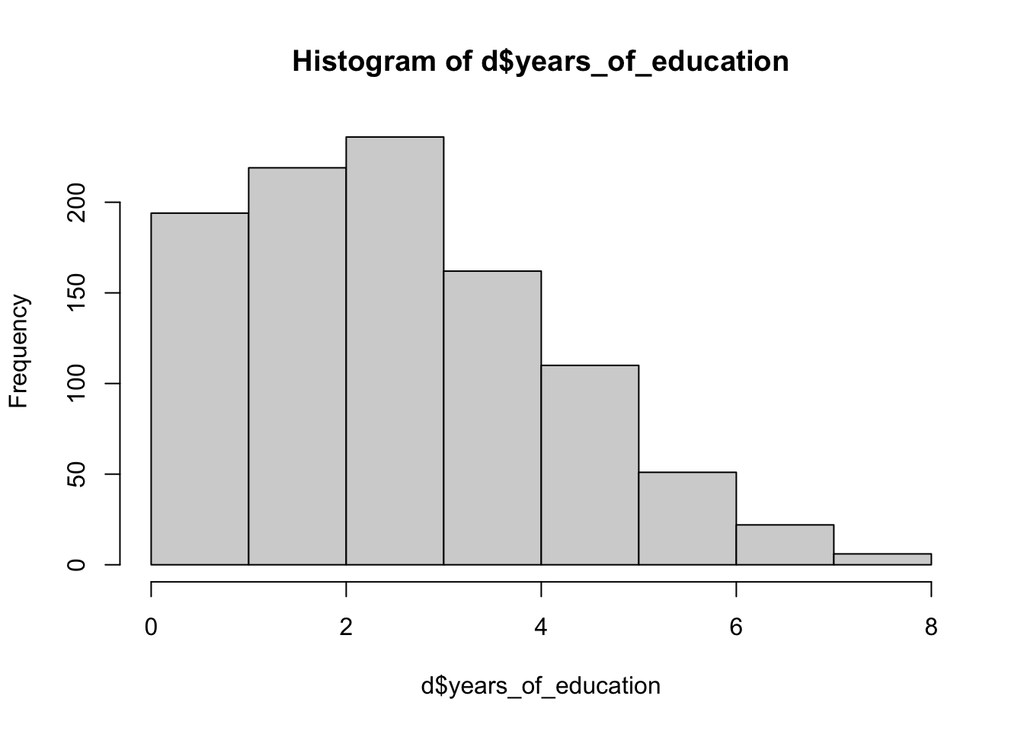

```r
# Zombies killed does not follow a normal distribution
#It looks like a binomial or poisson distribution

hist(d$years_of_education)
```

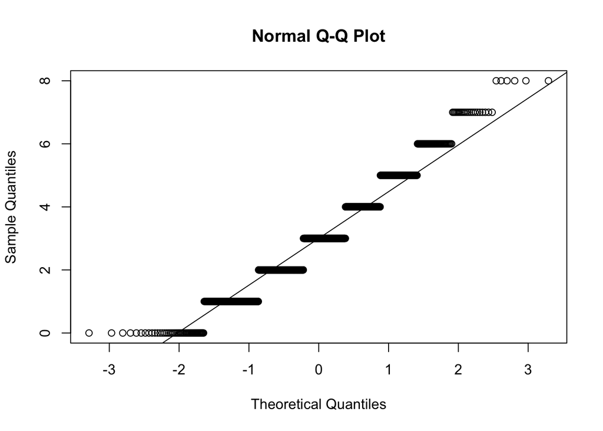

```r
qqnorm(d$years_of_education)
qqline(d$years_of_education)
```

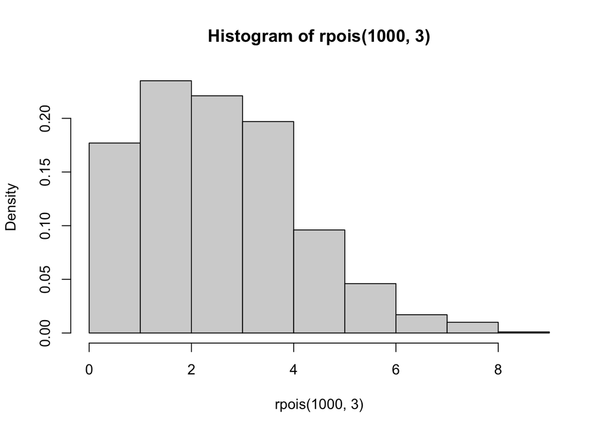

```r
# Years of education does not follow a normal distribution
# It looks like a binomial or poisson distribution

# Ok so I didn't visually verify the poisson distribution


hist(rpois(1000,3), probability = T )
```

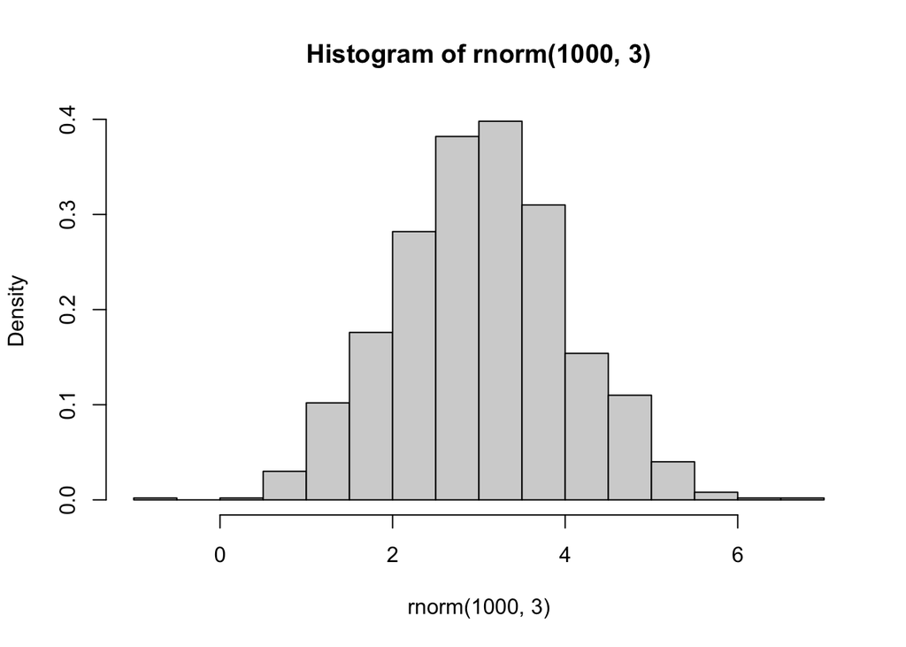

```r
hist(rnorm(1000,3), probability = T )
```

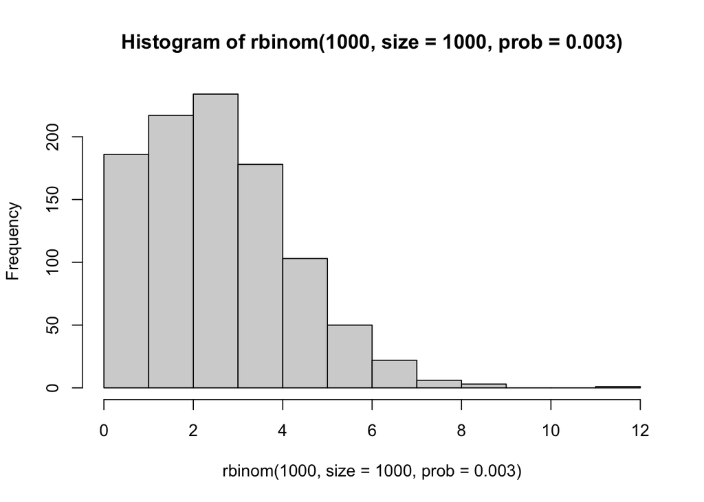

```r
hist(rbinom(1000, size = 1000, prob = .003)) # This graph is weird
```

5. Now use the sample() function to sample ONE subset of 30 zombie survivors (without replacement) from this population and calculate the mean and sample standard deviation for each variable. Also estimate the standard error for each variable, and construct the 95% confidence interval for each mean. Note that for the variables that are not drawn from the normal distribution, you may need to base your estimate of the CIs on slightly different code than for the normal…

```r
s_height <- sample(d$height, size = 30, replace = FALSE)
m_height <- mean(s_height)
m_height
```

```
## [1] 66.72497
```

```r
sd_height <- sd(s_height)
sd_height
```

```
## [1] 4.062027
```

```r
sem_height <- sd(s_height)/sqrt(length(s_height))
sem_height
```

```
## [1] 0.7416212
```

```r
lower_height <- m_height - qt(1 - 0.05/2, df = 30 - 1) * sem_height
upper_height <- m_height + qt(1 - 0.05/2, df = 30 - 1) * sem_height
ci_t_height <- c(lower_height, upper_height)
ci_t_height
```

```
## [1] 65.20819 68.24176
```

```r
s_weight <- sample(d$weight, size = 30, replace = FALSE)
m_weight <- mean(s_weight)
m_weight
```

```
## [1] 148.1789
```

```r
sd_weight <- sd(s_weight)
sd_weight
```

```
## [1] 18.70343
```

```r
sem_weight <- sd(s_weight)/sqrt(length(s_weight))
sem_weight
```

```
## [1] 3.414764
```

```r
lower_weight <- m_weight - qt(1 - 0.05/2, df = 30 - 1) * sem_weight
upper_weight <- m_weight + qt(1 - 0.05/2, df = 30 - 1) * sem_weight
ci_t_weight <- c(lower_weight, upper_weight)
ci_t_weight
```

```
## [1] 141.1949 155.1628
```

```r
s_age <- sample(d$age, size = 30, replace = FALSE)
m_age <- mean(s_age)
m_age
```

```
## [1] 19.41269
```

```r
sd_age <- sd(s_age)
sd_age
```

```
## [1] 2.562176
```

```r
sem_age <- sd(s_age)/sqrt(length(s_age))
sem_age
```

```
## [1] 0.4677872
```

```r
lower_age <- m_age - qt(1 - 0.05/2, df = 30 - 1) * sem_age
upper_age <- m_age + qt(1 - 0.05/2, df = 30 - 1) * sem_age
ci_t_age <- c(lower_age, upper_age)
ci_t_age
```

```
## [1] 18.45595 20.36942
```

```r
s_zombies_killed <- sample(d$zombies_killed, size = 30, replace = FALSE)
m_zombies_killed <- mean(s_zombies_killed)
m_zombies_killed
```

```
## [1] 3.233333
```

```r
sd_zombies_killed <- sd(s_zombies_killed)
sd_zombies_killed
```

```
## [1] 2.144493
```

```r
sem_zombies_killed <- sd(s_zombies_killed)/sqrt(length(s_zombies_killed))
sem_zombies_killed
```

```
## [1] 0.3915291
```

```r
# This is wrong

lower_zombies_killed <- m_zombies_killed - qpois(1 - 0.05/2, kill_sum$zombies_killed) * sem_zombies_killed
upper_zombies_killed <- m_zombies_killed + qpois(1 - 0.05/2, kill_sum$zombies_killed) * sem_zombies_killed
ci_t_zombies_killed <- c(lower_zombies_killed, upper_zombies_killed)
ci_t_zombies_killed
```

```
## [1] 0.4926298 5.9740369
```

```r
# needed to normalize data set

z_set <- NULL
for (i in 1:10000) {
z_set[i] <- mean(sample(s_zombies_killed, 30, replace = TRUE))
 }
quantile(z_set, c(0.025, 0.975))
```

```
##     2.5%    97.5%
## 2.466667 4.033333
```

```r
s_years_of_education <- sample(d$years_of_education, size = 30, replace = FALSE)
m_years_of_education <- mean(s_years_of_education)
m_years_of_education
```

```
## [1] 2.733333
```

```r
sd_years_of_education <- sd(s_years_of_education)
sd_years_of_education
```

```
## [1] 1.638614
```

```r
sem_years_of_education <- sd(s_years_of_education)/sqrt(length(s_years_of_education))
sem_years_of_education
```

```
## [1] 0.2991687
```

```r
# This is wrong

lower_years_of_education <- m_years_of_education - qpois(1 - 0.05/2, educate_sum$years_of_education) * sem_years_of_education
upper_years_of_education <- m_years_of_education + qpois(1 - 0.05/2, educate_sum$years_of_education) * sem_years_of_education
ci_t_years_of_education <- c(lower_years_of_education, upper_years_of_education)
ci_t_years_of_education
```

```
## [1] 0.6391524 4.8275143
```

```r
# needed to normalize data set

e_set <- NULL
for (i in 1:10000) {
e_set[i] <- mean(sample(s_years_of_education, 30, replace = TRUE))
 }
quantile(e_set, c(0.025, 0.975))
```

```
##     2.5%    97.5%
## 2.200000 3.333333
```

6. Now draw 99 more random samples of 30 zombie apocalypse survivors, and calculate the mean for each variable for each of these samples. Together with the first sample you drew, you now have a set of 100 means for each variable (each based on 30 observations), which constitutes a sampling distribution for each variable. What are the means and standard deviations of this distribution of means for each variable? How do the standard deviations of means compare to the standard errors estimated in [5]? What do these sampling distributions look like (a graph might help here)? Are they normally distributed? What about for those variables that you concluded were not originally drawn from a normal distribution?

```r
x_height <- NULL
for (i in 1:99) {
  x_height[i] <- mean(sample(d$height, size = 30, replace = FALSE))
}
all_height <- c(m_height, x_height)
m_all_height <- mean(all_height)
m_all_height
```

```
## [1] 67.80864
```

```r
sd_all_height <- sd(all_height)
sd_all_height
```

```
## [1] 0.728613
```

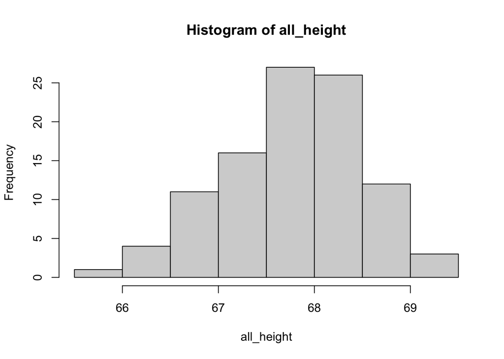

```r
# The standard deviation here is very similar to the standard error in the last step

hist(all_height)
```

```r
# The distribution looks normal

x_weight <- NULL
for (i in 1:99) {
  x_weight[i] <- mean(sample(d$weight, size = 30, replace = FALSE))
}
all_weight <- c(m_weight, x_weight)
m_all_weight <- mean(all_weight)
m_all_weight
```

```
## [1] 143.6439
```

```r
sd_all_weight <- sd(all_weight)
sd_all_weight
```

```
## [1] 3.098761
```

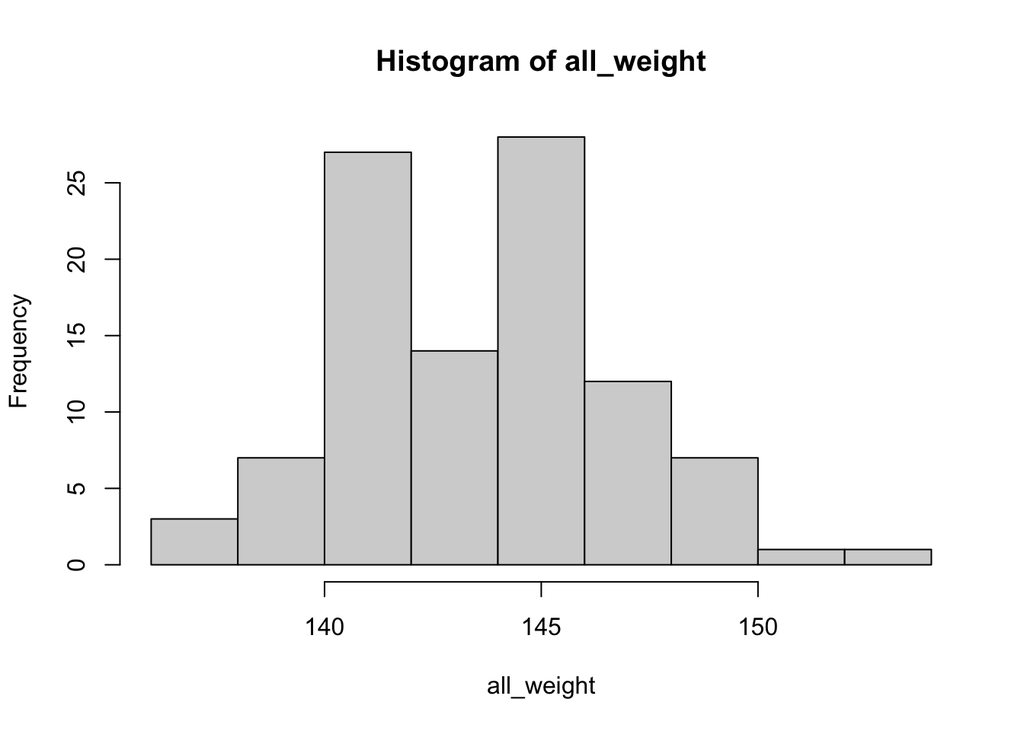

```r
# The standard deviation here is very similar to the standard error in the last step

hist(all_weight)
```

```r
# The distribution looks normal

x_age <- NULL
for (i in 1:99) {
  x_age[i] <- mean(sample(d$age, size = 30, replace = FALSE))
}
all_age <- c(m_age, x_age)
m_all_age <- mean(all_age)
m_all_age
```

```
## [1] 20.02848
```

```r
sd_all_age <- sd(all_age)
sd_all_age
```

```
## [1] 0.5317085
```

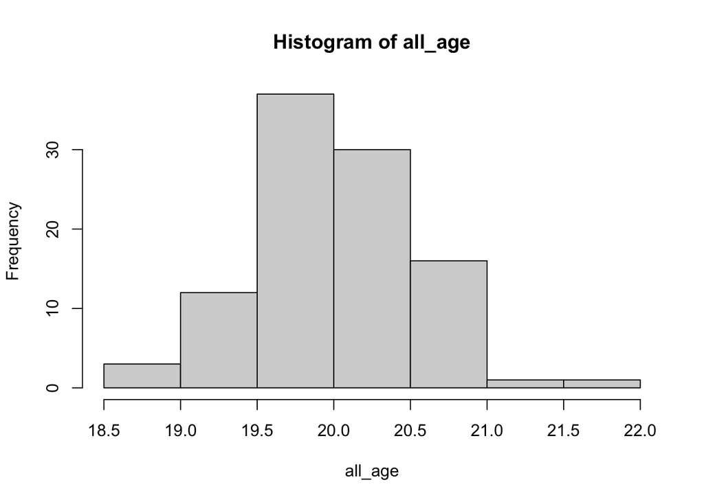

```r
# The standard deviation here is very similar to the standard error in the last step

hist(all_age)
```

```r
# The distribution looks normal

x_zombies_killed <- NULL
for (i in 1:99) {
  x_zombies_killed[i] <- mean(sample(d$zombies_killed, size = 30, replace = FALSE))
}
all_zombies_killed <- c(m_zombies_killed, x_zombies_killed)
m_all_zombies_killed <- mean(all_zombies_killed)
m_all_zombies_killed
```

```
## [1] 3.005667
```

```r
sd_all_zombies_killed <- sd(all_zombies_killed)
sd_all_zombies_killed
```

```
## [1] 0.3219279
```

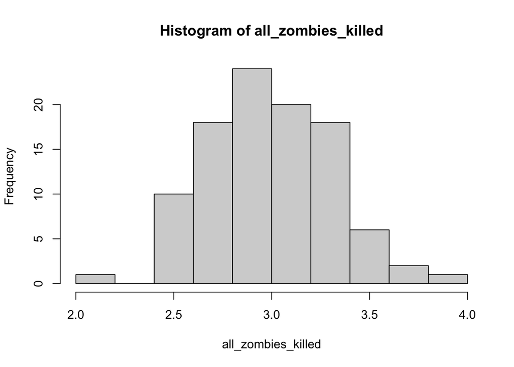

```r
# The standard deviation here is very similar to the standard error in the last step

hist(all_zombies_killed)
```

```r
# The distribution looks normal

x_years_of_education <- NULL
for (i in 1:99) {
  x_years_of_education[i] <- mean(sample(d$years_of_education, size = 30, replace = FALSE))
}
all_years_of_education <- c(m_years_of_education, x_years_of_education)
m_all_years_of_education <- mean(all_years_of_education)
m_all_years_of_education
```

```
## [1] 3.032
```

```r
sd_all_years_of_education <- sd(all_years_of_education)
sd_all_years_of_education
```

```
## [1] 0.3042874
```

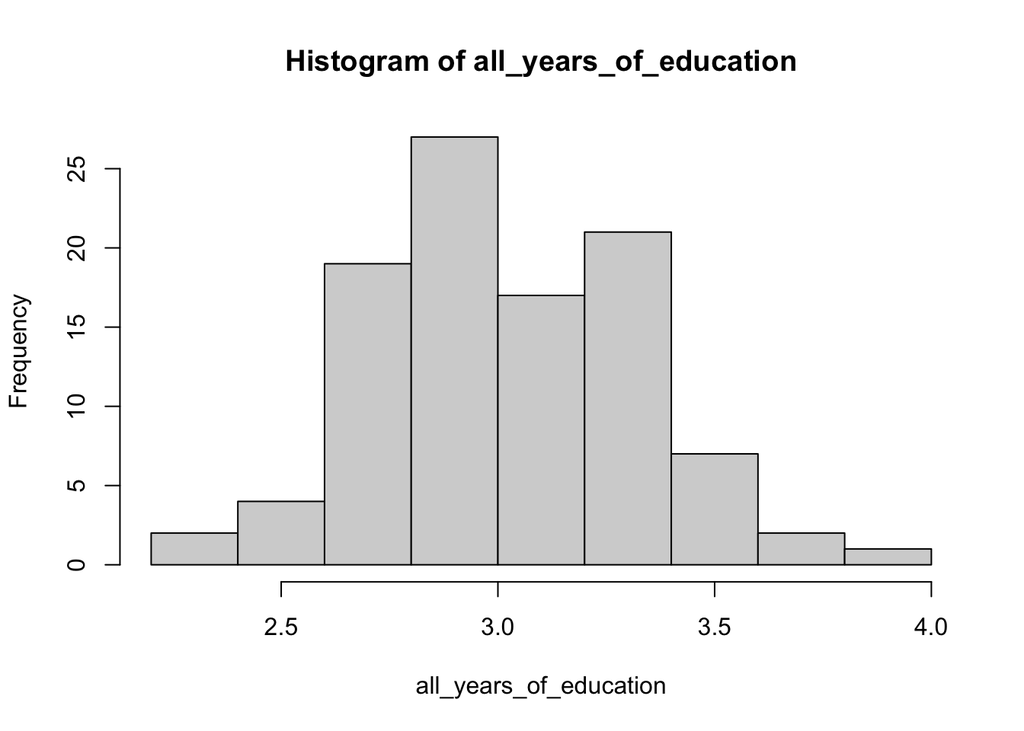

```r
# The standard deviation here is very similar to the standard error in the last step

hist(all_years_of_education)
```

```r
# The distribution looks normal
```